Skip to main content

# Research

## Introduction

My research focuses on genetic modeling, which consists in building a representation of how inheritance determines the expression of phenotypes. Inheritance was long studied through the mere relatedness between individuals. Genomic markers, then whole genome sequencing, now provide an increasingly complete picture of its physical support. This information, together with the growth of computational means, opens new challenges for genetic modeling.

The goals of my research are, on the one hand, to optimize the **efficiency of breeding**, and, on the other hand, to understand **how the genome expresses** from a more fundamental perspective.

All my work can be read as successive answers to one question:

> How to estimate, and how to interpret, the genetic variances and covariances between traits when their number grows?

Each phenotypic trait has a genetic variance, which tells how much it can respond to selection. Each pair of traits shares a genetic covariance, which tells how selecting on one trait moves the other. Gathered over a set of traits, these quantities form a genetic covariance matrix. In breeding, this matrix tells how much leverage selection has on each trait and how traits constrain each other. The notion of trait can be stretched: the same phenotype measured in different environments, or the parameters describing its response along a gradient (such as temporal or environmental), can all be handled as distinct traits.

As my research progressed, this matrix kept growing, and with it a statistical difficulty: the number of parameters grows quadratically with the number of traits, and their estimation quickly becomes unstable, then impossible.

The following sections retrace these steps, and what each of them required:

- Section 1 recalls the core concepts of quantitative genetics and the genetic mixed model, the tool used to estimate these variances and covariances.
- Section 2 extends the matrix across traits: bivariate genomic prediction, then a 6-trait Bayesian model and the behavior of its priors.
- Section 3 extends it along an environmental gradient: random regression, and what it reveals about plasticity, heterosis and trade-offs between traits.
- Section 4 reduces it, either *a posteriori* by collapsing several traits into a single index, either *a priori* by limiting the estimation to the principal components of the covariance (factor analytic).
- Section 5 presents pyreml, a differentiable mixed model solver running on GPU, and the open question of how far mixed models and neural networks can be joined.

## 1 Modeling phenotypes

### 1.1 Core quantitative genetics concepts

If we were to identify a single starting point to the science of quantitative genetics, it would be Fisher’s seminal paper (Fisher 1918), which simultaneously: reconciled Mendelian genetics with the Darwinian theory of evolution; identified the relevance of reasoning with variances and coined the concept of heritability; and proposed the analysis of variance, which is both the first genetic model and a foundation of modern statistics. In a nutshell, the central limit theorem allows countless infinitesimal effects with a Mendelian inheritance to explain the continuous distribution of quantitative traits, which fits the Darwinian view of how natural selection shapes species.

From its very origin, quantitative genetics is therefore both a statistical and an evolutionary discipline. This dual nature runs through all that follows.

Reasoning with variances:

$$\sigma^2_P = \sigma^2_G + \sigma^2_E,
\qquad
H^2 = \frac{\sigma^2_G}{\sigma^2_P},$$

with $\sigma^2_P$ the phenotypic variance, $\sigma^2_G$ the genetic variance and $\sigma^2_E$ the environmental variance. $H^2$ is the broad-sense heritability. From this fundamental equation have been derived:

- $\sigma^2_P = \sigma^2_G + \sigma^2_E + \sigma^2_{G \times E}$ (Falconer 1989), with a genotype-by-environment interaction variance component.
- $\sigma^2_G = \sigma^2_A + \sigma^2_D + \sigma^2_I$ (Falconer 1989), with respectively the additive, dominance and epistatic variances; and $h^2 = \sigma^2_A / \sigma^2_P$ the narrow-sense heritability.
- $\sigma^2_G = \sigma^2_{A_\alpha} + \sigma^2_{A_\beta} + \sigma^2_{D}$ (Comstock et al. 1949; Stuber and Cockerham 1966), specific to the hybrid breeding context, with the additive variances associated with the general combining abilities (GCA) of two heterotic groups $\alpha$ and $\beta$, and the dominance variance associated with the specific combining ability (SCA) of each hybrid family.

Accessing the narrow-sense heritability (or a partial heritability per heterotic group in the latter case) is pivotal in breeding, as it determines the efficiency of selection as given by the breeder’s equation $R = \rho\,\sigma_A\,i$, with $R$ the response to selection, $\rho$ the accuracy ($\rho = h$ when selecting directly on phenotypes), and $i$ the selection intensity. The same equation describes the response of a natural population to selection; only the origin of the selective pressure differs.

### 1.2 The genetic mixed model

Fisher had the intuition of working on variances, but did not exploit it to its full extent. Henderson (Henderson 1949; Henderson 1975) introduced the linear mixed model (LMM), which effectively implemented and fully leveraged random effects in Fisher’s ANOVA model. For an accessible introduction to LMM random effects, see for instance pyreml’s [doc](https://ai-for-genome-interpretation-lab.github.io/pyreml/fixed_random.html) (Marchal, Trottier, et al. 2026).

Considering a basic genetic LMM:

$$y_i = \mu + a_i + r_i,
\qquad
a \sim N(0, \sigma^2_A \mathbf{A}),
\qquad
r \sim N(0, \sigma^2_R \mathbf{I}),$$

with $y$ a phenotypic trait, $\mu$ the population mean, $a_i$ the breeding value of individual $i$, $r_i$ a residual of variance $\sigma^2_R$ and $\mathbf{I}$ an identity matrix. The breeding value is conceptually close to the additive effect *sensu stricto*, but it also encompasses the average effect of non-additive components over the population, given the distribution of allele frequencies, *i.e.* the genetic background of the population. The variances ($\sigma^2_A$, $\sigma^2_R$) are estimated in a computationally intensive step, the restricted maximum likelihood (REML) (Patterson and Thompson 1971; Harville 1977).

Considering $a$ as random has 2 major advantages:

- $a$ is a best linear unbiased predictor (BLUP), which means it is shrunk (or regularized, in machine learning terminology). This allows fitting a largely under-determined system and maximizes the generalizability of the inference.
- The covariance of $a$ has a known structure $\mathbf{A}$, the kinship, built either from the pedigree (Malécot 1948; Mrode and Thompson 2005) or from molecular information (Meuwissen et al. 2001; VanRaden 2008).

In the latter case, the model is called a genomic BLUP (GBLUP) and is often based on markers such as SNPs. Noteworthily, the markers do not have to be causal: the effect of causal QTLs is captured by the linkage disequilibrium between them and the markers.

Two features of this model matter for the rest of this page. First, the kinship is nothing more than a similarity matrix between individuals: in machine learning terms, a kernel. Nothing in the model requires that this similarity come from genetics, which is what we exploit in Section 4.3. Second, the variances are not a by-product of the fit: they are the quantities of interest, because they carry the biological meaning (heritability, genetic correlations). This is why I care so much about estimating them without bias, all the way to Section 5.

The genetic LMM, based on either pedigree or markers, and the concepts behind it, frame my research.

## 2 Phenotypes are multivariate

My first research topic took place in the context of hybrid oil palm breeding, where I focused on the performance of bivariate modeling (Cros 2014; Marchal 2014; Marchal et al. 2016).

I then continued in perennial crop breeding with a PhD on a hybrid forest tree: the European $\times$ Japanese larch. Phenotypes are multivariate, and the full picture is essential for the breeder to make informed decisions: the heritability of each trait tells how much leverage is available, and the genetic correlations act as a constraint system, as selecting on one trait impacts all the others. The goal of the first chapter of my PhD was to draw this full picture for hybrid larch, estimating all genetic parameters along with heterosis and in relation to G$\times$E interactions (Marchal et al. 2017, 2019; Marchal 2018).

In this section, I present the multivariate genetic model used in both research projects, then how bivariate modeling improves hybrid oil palm breeding, and finally how high-dimensional modeling was achieved during my PhD.

### 2.1 Multivariate genetic mixed model

All my experience in breeding concerned primarily hybrid crops. Here, the parents of the hybrids were heterozygous populations (for oil palm) or species (for larch). The model presented here is designed for these specificities (Stuber and Cockerham 1966; Cros 2014; Marchal 2018):

$$\begin{pmatrix} y_1 \\ y_2 \\ \vdots \\ y_p \end{pmatrix} =
\begin{pmatrix} \mu_1 \\ \mu_2 \\ \vdots \\ \mu_p \end{pmatrix} +
\begin{pmatrix} g_{\alpha1} \\ g_{\alpha2} \\ \vdots \\ g_{\alpha p} \end{pmatrix} +
\begin{pmatrix} g_{\beta1} \\ g_{\beta2} \\ \vdots \\ g_{\beta p} \end{pmatrix} +
\begin{pmatrix} s_{1} \\ s_{2} \\ \vdots \\ s_{p} \end{pmatrix} +
\begin{pmatrix} r_1 \\ r_2 \\ \vdots \\ r_p \end{pmatrix},$$

with:

- $y_j$ the phenotype $j$ of average $\mu_j$;
- $g_{\alpha j}$, $g_{\beta j}$ and $s_{j}$ the GCA of group $\alpha$, $\beta$, and the SCA respectively;
- $r_j$ the residual.

Both the genetic effects and the residual are taken as random:

$$g_\alpha \sim \mathcal{N}(0, \mathbf{\Sigma}_\alpha \otimes \mathbf{K}_\alpha)
\qquad
g_\beta \sim \mathcal{N}(0, \mathbf{\Sigma}_\beta \otimes \mathbf{K}_\beta)
\qquad
s \sim \mathcal{N}(0, \mathbf{\Sigma}_D \otimes \mathbf{D})
\qquad
r \sim \mathcal{N}(0, \mathbf{\Sigma}_R \otimes \mathbf{I})$$

with $\mathbf{K}_\alpha$ and $\mathbf{K}_\beta$ built from pedigree, molecular markers or both (Legarra et al. 2009); and $\mathbf{D} = \mathbf{K}_\alpha \otimes \mathbf{K}_\beta$ (Lynch and Walsh 1998; Ovaskainen et al. 2008). All the covariance matrices $\mathbf{\Sigma}_\alpha$, $\mathbf{\Sigma}_\beta$, $\mathbf{\Sigma}_D$ and $\mathbf{\Sigma}_R$ are full and contain $(p^2 + p) /2$ elements to estimate. Because the biological models (oil palm populations, larch species) are heterozygous (unlike, for instance, maize or *Arabidopsis thaliana* fixed lines), Mendelian segregation is involved (full sibs are not clones):

- $\mathbf{\Sigma}_{\alpha\,jj} =½\,\sigma^2_{A\alpha\,j}$,
- $\mathbf{\Sigma}_{\beta\,jj} = ½\,\sigma^2_{A\beta\,j}$,
- $\mathbf{\Sigma}_{D\,jj} = ¼\,\sigma^2_{D\,j}$,

with the residual capturing the individual genetic variation, *i.e.* the remaining $½$ of the additive variance and $¾$ of the dominance variance. Finally, any genetic correlation (additive $r_{A\alpha}$ and $r_{A\beta}$, or dominance $r_{D}$) is straightforwardly obtained as:

$$r_{ij} = \frac{\mathbf{\Sigma}_{ij}}{\sqrt{\mathbf{\Sigma}_{ii}\mathbf{\Sigma}_{jj}}}.$$

### 2.2 Bivariate modeling improves the analysis accuracy

GBLUP may benefit from multivariate modeling, especially for strongly correlated traits with unbalanced heritabilities or missing values (Calus and Veerkamp 2011; Jia and Jannink 2012; Guo et al. 2014). During my internship at Cirad, I analyzed a hybrid oil palm progeny test laid out as an incomplete factorial, located in North Sumatra, whose data had been collected over 5 years. At the time of the study, the oil palms had been genotyped with SSRs, and a significant part of the research consisted in adapting GBLUP to multi-allelic markers. I focused on two elementary components of oil yield, known to be strongly correlated: the number of bunches (BN) and their average weight (ABW).

We can distinguish two accuracies. On the one hand, the selection accuracy $cor(u, \hat{u})$ for a given genetic value $u$ (GCA from group $\alpha$ or $\beta$, or SCA) was derived from the model prediction error variances. The selection accuracy matters most to the breeder, as it is $\rho$ in the breeder’s equation $R = \rho\,\sigma_A\,i$ when selecting from a GBLUP model. On the other hand, I also considered the prediction accuracy $cor(y, \hat{G})$, with $\hat{G}$ the predicted total genetic value (*i.e.* the sum of all genetic components).

The main result is summarized in Figure 1: bivariate modeling of BN and ABW brought a large and significant improvement of the selection accuracy for GCA. This result was also confirmed for the SCA of observed and non-observed hybrid combinations. The two traits are strongly (negatively) correlated, which partly explains this result. However, unlike the textbook cases of the literature, BN and ABW show no extreme pattern of missing values or of heritabilities (heritabilities range from 0.23 to 0.57, Cros et al. 2015). Multivariate modeling can thus improve GBLUP selection accuracy even in this configuration.

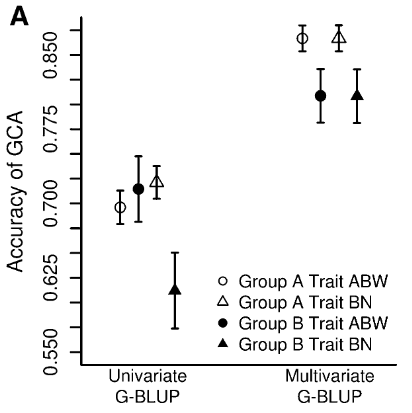

Figure 1: Improvement in the GCA selection accuracy for both heterotic groups A and B, and for both traits BN and ABW, when using a bivariate GBLUP instead of a univariate one (from Marchal et al. 2016).

I also carried out a cross-validation, which did not confirm a gain in prediction accuracy (Marchal 2014). This is less contradictory than it seems: the model’s main goal is not to brute-force predict the phenotype $y$, but to obtain the most accurate representation of its genetic components. The most conclusive test would be to observe how selection decisions based on univariate and bivariate models perform in a new generation, thus actually applying the breeder’s equation to assess $\rho$ *a posteriori*.

### 2.3 High dimension modeling: the “full picture”

In the previous section, I expanded from a univariate to a bivariate model to gain accuracy. In the context of my PhD at INRAE-Orléans, my goal was different: estimating the whole genetic correlation structure for its own sake, as it is key information for breeding. The hybrid larch progeny test was a full diallel between 9 European larches (*Larix decidua*) and 9 Japanese larches (*L. kaempferi*), observed on 3 sites in an incomplete block design. Being a diallel, it included all 3 taxa (both parental species and the hybrid). I first fitted a univariate model to account for spatial effects within each site, including all taxa for a complete spatial representation. Then, I performed the multivariate analyses of 6 phenotypic traits taxon by taxon, with a GCA model for the hybrids. I used the latest measurements available: the trees had been growing since 1997 on sites SA and SS and since 2004 on site PC, with regular phenotyping campaigns. No markers were available, so all kinships were pedigree-based.

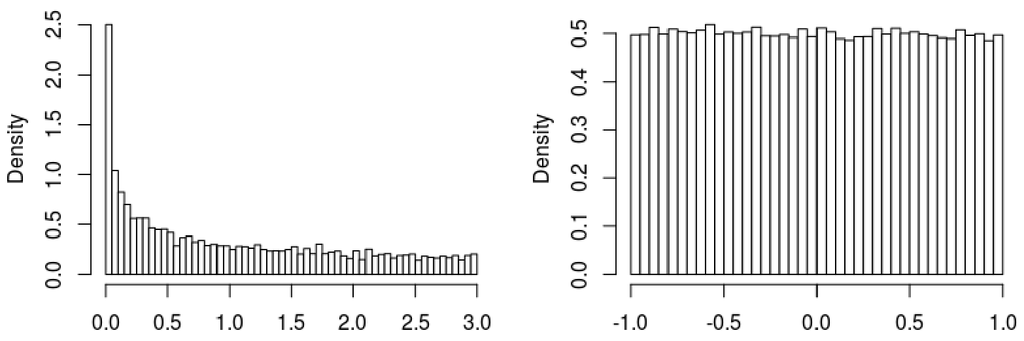

Figure 2: Marginal prior for the variances (a) and the correlations (b), from a PX inverse-Wishart ($p = 6$ dimensions, $\mathbf{V} = \mathbf{I_6}$, $\nu = p + 1 = 7$), and PX hyperparameters $\mathbf{V_\alpha} = 1000\,\mathbf{I_6}$, $\mu_\alpha = 0$ (from Marchal 2018)

After obtaining apparently converged Markov chains, I could draw the full inference over all genetic parameters, including all genetic correlations between traits, as summarized in Figure 3. Based on the 95% credible intervals (CI), some of these correlations were significantly different from $0$, notably between BHC and HT, and between HT and DEN, indicating that taller trees tend to be both larger and denser. This is good news for breeding: these 3 traits, all with a positive economic value, can be improved together.

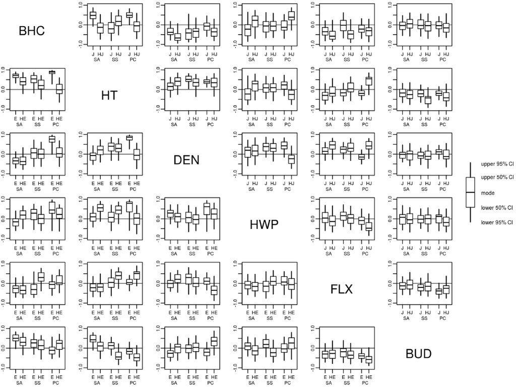

Figure 3: Genetic additive correlations between 6 traits of interest for larch breeding: breast-height circumference (BHC), height (HT), wood density (DEN), heartwood proportion (HWP), stem flexuosity (FLX), bud flush phenology (BUD); observed in 3 sites (SA, SS, PC); either in pure species (E and J for European and Japanese larch respectively) or in hybridization (HE and HJ respectively) (from Marchal et al. 2017).

One difficulty met here stayed with me: with 6 traits, each covariance matrix already holds 21 parameters, and their number grows quadratically with the number of traits. Some of these models took weeks to run, and as traits are added, estimating all parameters both fast and reliably becomes out of reach, which calls for more parsimonious structures such as the factor-analytic model (Section 4.2).

## 3 Phenotypes are plastic

Phenotypic plasticity is a broad topic, covering all possible cases of G$\times$E interaction. As a textbook illustration, queen and worker bees show no specific genetic difference, and their caste is determined by the food they receive as larvae. We focus here on how the environment shapes the phenotypes of plants. Though not as categorical as caste determination in hymenopterans, plasticity is of singular importance in plants, which by definition cannot escape the soil and weather they are exposed to throughout their life thus are constrained to adapt to it.

### 3.1 Modeling plasticity

G$\times$E interactions can be tackled from two modeling perspectives, which correspond to the two classical views of plasticity in evolutionary biology (Schlichting and Pigliucci 1998).

The first perspective considers the phenotypes observed in different environments as different traits, as announced in the introduction. It therefore relies on a discrete definition of the environment, and it can be handled with a multivariate genetic model, except for the residual, for which $\mathbf{\Sigma}_R$ reduces to a diagonal matrix (different environments share no observation, hence no residual correlation). This is common in agriculture, where the same genotypes are observed in a multi-environment trial network (MET). In this view, a genetic correlation lower than $1$ between two environments is precisely G$\times$E.

The second perspective considers the environment as continuous instead of discrete. The phenotype is then better described by a function along the environmental covariate, *i.e.* a reaction norm. This view was central to my PhD, and led me to a 3-month research visit to Carl Schlichting’s laboratory (University of Connecticut, Department of Ecology and Evolutionary Biology). Modeling these reaction norms raises a colinearity problem as soon as we try to model curvature. The most straightforward idea would be to model the phenotype as a polynomial of the environmental factor, *e.g.* of order 3: $\beta_0 + \beta_1 e^1 + \beta_2 e^2 + \beta_3 e^3$. By construction, $e$ and $e^2$ often show extremely high correlation. Centering $e$ around $0$ makes $cor(e, e^2) = 0$, but it does not fix $cor(e, e^3)$, which remains high. The problem worsens with higher order polynomials and calls for a systematic solution. One solution consists in using Legendre polynomials, which are mutually orthogonal at any order on $[-1, 1]$ (Kirkpatrick et al. 1990; Schaeffer 2004; Meyer and Kirkpatrick 2005). Let us consider $\mathcal{L}_m(e)$, the $m^\text{th}$ Legendre polynomial applied to $e$ after a linear transformation bringing all $e$’s to $[-1, 1]$.

The random regression genetic model can then be defined (neglecting the SCA for parsimony):

$$y_{ijklt} =
\sum^{M_b}_{m=0} b_{m} \mathcal{L}_m(e_t) +
\sum^{M_\alpha}_{m=0} g_{\alpha\,im} \mathcal{L}_m(e_t) +
\sum^{M_\beta}_{m=0} g_{\beta\,jm} \mathcal{L}_m(e_t) +
\sum^{M_p}_{m=0} p_{km} \mathcal{L}_m(e_t) +
r_{ijklt}$$

with $y_{ijklt}$ the $l^\text{th}$ observation of individual $k$, of parents $i$ and $j$, at the $t^\text{th}$ point of the environmental gradient. The population reaction norm is given by $b$, the only fixed part of the model. There is now one GCA $g$ per heterotic group $\alpha$ and $\beta$ and per polynomial order $m$. Each order $M_b, M_\alpha, M_\beta$ and $M_p$ could theoretically be tuned independently. The permanent environment effect $p_{km}$ captures all individual variation not captured by the modeled genetic components. The random effects follow:

- $g_\alpha \sim \mathcal{N}(0, \mathbf{\Sigma}_\alpha)$, and likewise for $g_\beta$;
- $p \sim \mathcal{N}(0, \mathbf{\Sigma}_p)$.

The residual $r$ is i.i.d. Here, $\mathbf{\Sigma}_\alpha$ is a covariance between the intercept, slope and curvature of the reaction norms: the same object as in the multivariate model, where “traits” are now polynomial coefficients. As for the multivariate genetic model, the challenging part remains the estimation of dense $\mathbf{\Sigma}$’s with $(p^2 + p) /2$ variance components. Consequently, the Bayesian framework that we designed for high-dimensional multivariate models can be used for random regression as well. The two approaches (random regression and multivariate modeling) can also be combined, as we did in the following sections; see for instance pyreml’s [doc](https://ai-for-genome-interpretation-lab.github.io/pyreml/variance_structures.html#left-hand-factor-mathbfsigma_a) (Marchal, Trottier, et al. 2026).

Though conceptually elegant, this model has statistical limitations:

- It requires many parameters, and in practice the first orders (those that do not require Legendre polynomials) are often sufficient.
- Modeling the residual $r$ as independent of $e$ is almost always a questionable choice. Modeling heteroscedasticity, as pyreml allows (Marchal, Trottier, et al. 2026), is pivotal to remain within the linear model assumptions in random regression.
- The model extrapolates very poorly, even within $[-1, 1]$, which can produce misleading insights, especially when $e$ does not start and end at the same point for all individuals.

### 3.2 Role of phenotypic plasticity in the construction of hybrid larch heterosis

As they grow exceptionally old and record variation in their growth rings, trees are a window to the past. This is especially interesting as their growth correlates with past climatic events. This section focuses on sites SA and SS of the experimental set-up previously described. Wood cores were sampled from each tree, reduced to a standard thickness and X-rayed to obtain a microdensitometric profile (Figure 4). Two traits were analyzed, for a given sample and a given year: ring width (RW) and ring mean density (RMD).

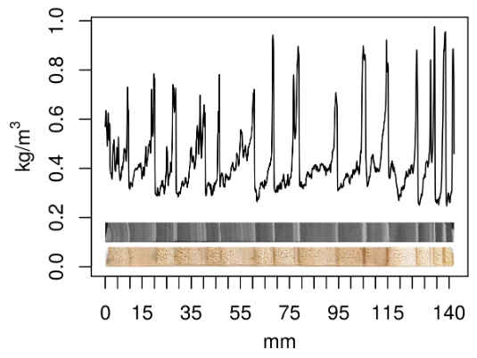

Figure 4: Microdensitometric profile (on top), obtained from the radiography (in the middle) of a wood core sample (at the bottom) (from Marchal et al. 2019).

To describe the environment, I developed a daily water availability model inspired by the closed-source, licensed model BILJOU© (Granier et al. 1999; Bréda et al. 2006; Marchal et al. 2019), adapted to the specificities of our trial: the leaf area index (LAI) varies over time, and the available water capacity (AWC) varies spatially. Neither was covered by BILJOU©. I estimated the increasing LAI over time from tree circumferences, measured throughout their growth. We measured AWC at contrasting locations of each site from soil pits, and I interpolated it using tree height BLUPs as a proxy. Finally, I summarized the information at the year level with “D1rew”, defined as the first decile of the daily relative extractable water (REW) in a given year. D1rew explained more phenotypic variance (about twice as much for RW) than “MJJA”, a simpler index built as the sum of precipitation during the growing season (May to August). Building the environmental axis is an important part of the model: a poorly defined gradient yields poorly defined reaction norms.

The core question of my PhD was the role of phenotypic plasticity in the construction of hybrid larch heterosis. To address it, I fitted an order 3 random regression model across sites SA and SS for each taxon (*L. decidua*, *L. kaempferi* or their hybrid). The fixed part of the model, *i.e.* the average reaction norm of each taxon within each site, is presented in Figure 5. On the one hand, heterosis (hybrid superiority) was expressed in RW, and was stronger with higher D1rew, *i.e.* higher water availability, a more favorable environment. Interestingly, the ranking between European and Japanese larches varied between sites for RW, but the hybrid always ranked first. On the other hand, the reaction norms of RMD were flat with respect to D1rew, the ranking between taxa was constant, and the hybrid displayed the average value of its parents, *i.e.* no heterosis.

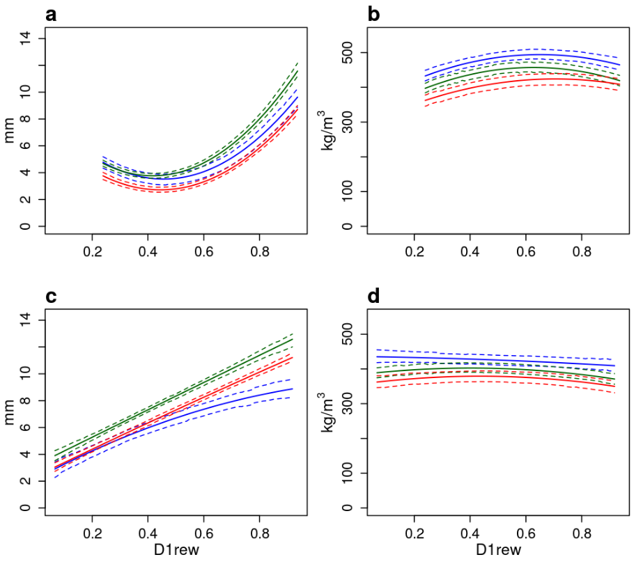

Figure 5: Reaction norms of RW (a, c) and RMD (b, d) along the environmental covariate D1rew, in the sites SA (a-b) and SS (c-d), for each taxon: European larch (in blue), Japanese larch (in red) and their hybrid (in green). Dashed lines: 95% credible intervals (from Marchal et al. 2019)

Heterosis is thus not a static property of the hybrid: it is itself a plastic trait.

### 3.3 Genetic parameters as longitudinal functions

To estimate all genetic variance parameters, I fitted an order 1 bivariate (RW + RMD) random regression model across sites, for each taxon. From the random regression perspective, the breeding values and GCAs, as well as all genetic variances and parameters derived from them, can be interpreted as functions of the environmental gradient (D1rew) (Figure 6, Figure 7, Figure 8). The Japanese larch showed more contrasted results, and for simplicity this section focuses on this taxon only.

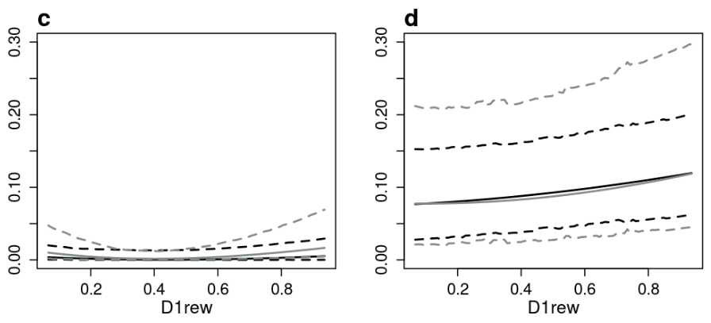

Figure 6: Narrow-sense heritabilities along D1rew for Japanese larch, for the traits: RW (c) and RMD (d). Black line: heritability in pure species crosses; and grey line: heritability in hybridization. Dashed lines: 95% credible intervals (from Marchal et al. 2019).

The heritability of RW was extremely low, whereas the heritability of RMD was estimable (around $h^2 = 0.10$), with a slight though non-significant trend to increase with higher D1rew (Figure 6). The heritability was identical in hybridization and in pure species breeding. The additive genetic correlation between RW and RMD, however, showed a clear pattern: positive or null (CI encompassing 0) at lower D1rew, it switched abruptly to negative at higher D1rew (Figure 7). The correlations in pure species and in hybridization both displayed this trend, though the negative correlation became significant (excluding 0) only in pure species.

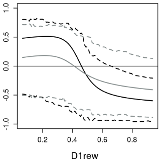

Figure 7: Additive genetic correlation between RW and RMD along D1rew, for Japanese larch. Black line: correlation in pure species crosses; and grey line: correlation in hybridization. Dashed lines: 95% credible intervals (from Marchal et al. 2019).

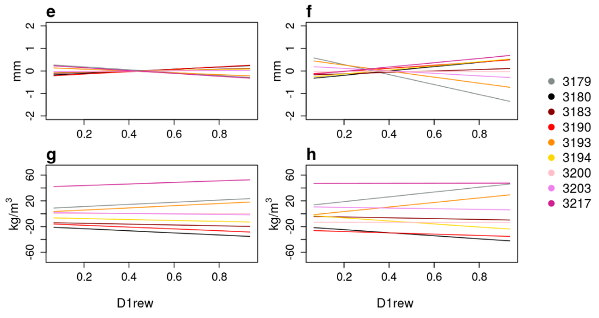

In a nutshell, the expression of all genetic contrasts was conditional on water availability: heterosis at the taxon level in growth (RW), and individual performances, especially in density (RMD). With high D1rew, a trade-off emerged between RW and RMD, which can be read as follows: favorable conditions are converted either into more wood (RW) or into denser wood (RMD), and genotypes differ in which way they go.

Here, favorable conditions revealed genetic differences, and with them a genetic constraint between two traits that was invisible under drought. For the breeder, this means that the genetic parameters estimated in one environment may not hold in another, and that the selection strategy itself should depend on the target environment.

## 4 Tackling the complexity

> What is simple is false, what is complicated is unusable. — Paul Valéry

In the previous sections, the genetic covariance matrices ($\mathbf{\Sigma}_\alpha$, $\mathbf{\Sigma}_\beta$, $\mathbf{\Sigma}_D$) kept growing: across traits in multivariate modeling, across intercept, slope and higher order components in random regression, and sometimes both. From now on, let us write $\mathbf{\Sigma_a}$ for any of them, so that the genetic value $a$ follows $a \sim \mathcal{N}(0, \mathbf{\Sigma_a} \otimes \mathbf{A})$, with $\mathbf{A}$ the kinship. In line with the introduction, a “trait” is any element with an entry in $\mathbf{\Sigma_a}$: a distinct phenotypic trait, the regression coefficient of a trait on a covariate, or its expression in an environment taken as discrete.

### 4.2 The factor-analytic model

The selection index acts *a posteriori*: it projects a multivariate system onto a single axis, and assumes that both $\mathbf{\Sigma_a}$ (used to design the index) and the breeding values or GCAs (upon which the projection applies) have been successfully estimated and predicted. The estimation step itself, however, can be very challenging in high dimension: the number of elementary variance parameters grows quadratically, $(p^2 + p) /2$, and is constrained by the positive-definiteness of $\mathbf{\Sigma_a}$. As $p$ grows, the variance parameters quickly become unidentifiable. The factor-analytic (FA) model tackles this problem (Smith et al. 2001; Kirkpatrick and Meyer 2004; Meyer 2009) by focusing on the estimation of the latent structure of a reduced-rank $\mathbf{\Sigma_a} = \mathbf{Q}\mathbf{\Lambda}\mathbf{Q}^\top + \mathbf{\Psi},$ with $\mathbf{Q}_{p \times q}$ an orthonormal matrix of $q$ principal components, $q \ll p$, $\mathbf{\Lambda}$ the eigenvalue-like importance of each axis, and $\mathbf{\Psi}$ the diagonal specificity matrix.

Frequentist FA mixed models are implemented in `ASReml` (Gilmour et al. 2009) and `Wombat` (Meyer 2006), both closed-source. FA has also been investigated in a Bayesian framework, using conjugate distributions (Nuvunga et al. 2019). At Seenovate, I hired and supervised an MSc intern to explore the core algorithmic steps of an FA implementation in a Bayesian framework with `stan`, whose no-U-turn sampler (NUTS) freed us from conjugacy constraints (Marchal, Lamure, et al. 2026). At CNRS, I then implemented this algorithm in a frequentist, open-source REML solver (Marchal, Trottier, et al. 2026).

The Bayesian FA research had 2 goals. The first was methodological: exploring an FA algorithm, implementing it in both a Gaussian and a negative-binomial generalized mixed model, and studying its sensitivity to the priors (Figure 9). The second, replacing the kinship with neural network embeddings, is presented in Section 4.3.

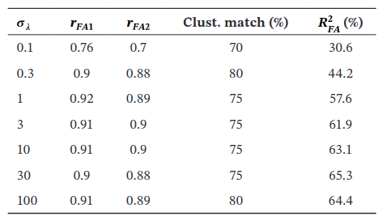

Figure 9: Prior sensitivity of the Bayesian factor-analytic Gaussian mixed model, using a centered half-Gaussian distributions for the elements of $\mathbf{\Lambda}$ with varying dispersion $\sigma^2_\lambda$, all other hyperparameters kept constant. The FA1 and FA2 accuracies ($r_{FA}$) are the correlations of the columns of $\hat{\mathbf{Q}}$ with the ground-truth, simulated $\mathbf{Q}$. The clustering match is defined as the match between the estimated and the ground-truth clusters of the simulation, from a 2-clusters segmentation. $R^2_{FA}$ is the proportion of variance captured by $\mathbf{Q}\mathbf{\Lambda}\mathbf{Q}^\top$ in opposition to $\mathbf{\Psi}$ (from Marchal, Lamure, et al. 2026).

Retrieving the latent structure can be a goal in itself: more than a computational trick reducing the number of parameters to estimate, the latent structure can be considered meaningful on its own. In quantitative genetics, its leading axes are the directions of the trait space along which most genetic variance lies, *i.e.* the directions along which selection, artificial or natural, is most effective. For this reason, Figure 9 focuses on the retrieval of a simulated latent structure. The model proved able to retrieve the latent structure under some hyperparameterizations, but showed a strong sensitivity to the prior.

I then implemented the FA model in a frequentist framework (pyreml, Marchal, Trottier, et al. 2026) and benchmarked it against the state-of-the-art, reference software `Wombat` (Meyer 2006, 2009). Switching from Bayesian to frequentist removed the question of prior sensitivity. The benchmark was carried out on the *Arabidopsis thaliana* 1001 genomes and the easyGWAS trait collection (Alonso-Blanco et al. 2016; Grimm et al. 2017), and the resulting estimated correlation circle is presented in Figure 10.

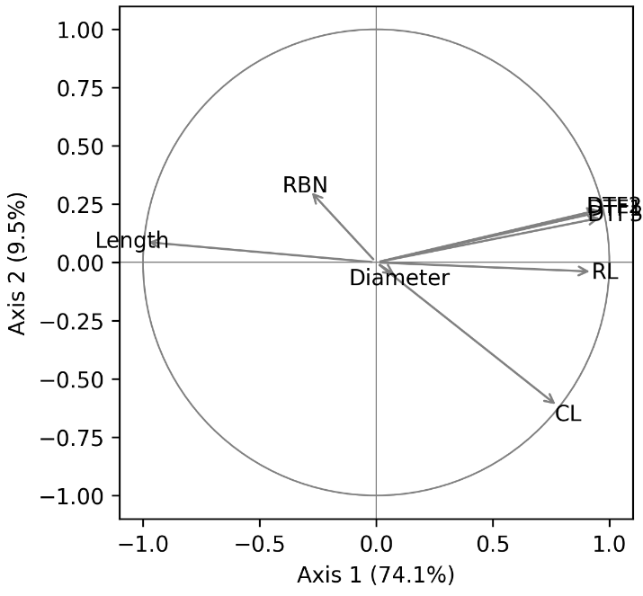

Figure 10: Correlation circle of *A. thaliana* traits, as directly inferred in a FA mixed model using pyreml, and which is consistent to the one estimated using `Wombat` (from Marchal, Trottier, et al. 2026)

As far as I know, this is the first open-source REML implementation of the FA mixed model. When adjusting pyreml convergence criterion to meet `Wombat`’s, both software led to the same estimates, which validated the algorithmic approach. pyreml, running on GPU (A100), was then 4 times faster than `Wombat` running on 64 CPUs.

### 4.3 Beyond genetic relatedness

The second goal of the Bayesian FA research was to demonstrate that the genomic kinship could be replaced by a kernel built from the embeddings of an encoder neural network (Marchal, Lamure, et al. 2026). Since the kinship is only a similarity matrix, the genetic framework extends to a broad variety of applications: encoders can provide a relatedness matrix between images, sounds, texts, sentiments, etc., and the mixed model can interpret these representations analytically through a variance decomposition. We illustrated this by analyzing how much of the number of citations of research papers is explained by their title, as encoded by a natural language processing model. The amount of variance explained was low, for several likely reasons:

- The negative-binomial model extracts little information from the data, as shown in the simulations.
- Our approach was naive and did not account for the many other factors influencing the number of citations.
- The encoder was taken as is, and was not fine-tuned to make its embeddings more explanatory.

Still, despite being low, the variance explained by the title was significant in cross-validation, which proves the concept. Concerning the last point, the mixed model and the encoder should ideally be trained together, on the same task. This is the starting point of my current research at CNRS (Section 5).

## 5 Current interests

In Section 4.3, I applied mixed-effect modeling to a kernel obtained from text embeddings. Conceptually, the encoder and the mixed model can be considered as a single model with two sub-units, with the latent embedding space as an interface between them. It would have been better to train the whole model, hence both sub-units, together. This raises the question of joining mixed model and neural network concepts in a single model, which is the topic of my post-doctoral research fellowship at CNRS. Mixed-effect neural networks (MENN) have already been investigated (Xiong et al. 2019; Simchoni and Rosset 2023); however, both approaches use a non-restricted likelihood loss resulting in biased variance estimates. The variances are both a quantity of interest, and the amount of shrinkage that regulates the BLUPs, so obtaining unbiased estimates is therefore pivotal. Exploring whether REML can be carried over to such models first required a REML solver that lives in the same computational world as neural networks: differentiable, and running on GPU.

### 5.1 pyreml: solving mixed models by REML gradient descent

Throughout the research described in the previous sections, I lacked an open-source, frequentist REML implementation allowing complex specifications such as kinships, multivariate and random regression structures, heteroscedastic residuals, and factor-analytic rank reduction. pyreml was developed to fill this gap (Marchal, Trottier, et al. 2026), with an uncommon approach. Most REML solvers are based on the expectation-maximization (EM) or average-information (AI) algorithms, which are well suited to estimating mixed model variances. pyreml, instead, builds a differentiable `PyTorch` graph of the REML loss and minimizes it by gradient descent. This lets `PyTorch` run the model resolution on GPU, greatly accelerating the computation. With some optimization (see the [doc](https://ai-for-genome-interpretation-lab.github.io/pyreml/training.html#reml)), notably replacing some automatic differentiation by closed forms and automatically using the Sherman–Morrison–Woodbury identity when advantageous, pyreml running on GPU outperforms the state-of-the-art software `Wombat` running on CPU, on a dense GBLUP benchmark of increasing size (Figure 11).

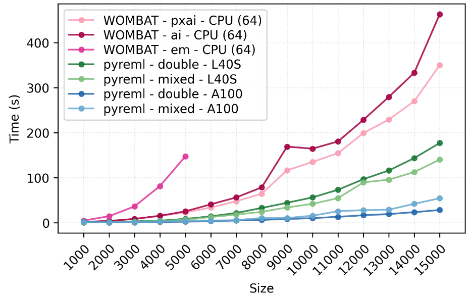

Figure 11: Benchmark comparing the computation time of pyreml to `Wombat` on a GBLUP of increasing $n$ simulated individuals, with a single observation by individual. Both genetic and residual variances taken as $10$ and initiated at $1$. pyreml runs on 2 different GPUs (L40S and A100), both on `float64` (“double”) numerical resolution and a custom (“mixed”) strategy consisting in pre-heating with `float32` and finishing on `float64`. `Wombat` runs on $64$ CPUs, and 3 algorithms are tested: AI (average information), EM (expectation-maximization) and PX-AI (a mix of parameter expansion and AI). EM was not run after $n > 5000$ as it was very slow, and all variance estimates and BLUP accuracies were identical across software, hardware and methods except for AI with $n \geq 10000$ (from Marchal, Trottier, et al. 2026).

Three aspects of this benchmark deserve attention beyond raw speed. First, the comparison is deliberately set on each tool’s own hardware: `Wombat` on a 64-CPU machine with its three algorithms, pyreml on GPU. Second, the “mixed” strategy is specific to the GPU world, as most commercial GPUs such as L40S are optimized for `float32` computation. The strategy consists in warming up in single precision and finishing in double precision, without loss on the final estimates. It is useless, even slightly counterproductive, on `float64` GPUs such as A100. Third, all methods converged to identical variance estimates and BLUP accuracies, except AI for $n \geq 10000$. This echoes the fragility of AI-REML already met with oil palm and larch (Section 2): the algorithm is fast when it works, but it can derail, whereas gradient descent on the REML loss converged to the common solution in all cases.

The genomic simulations were carried out using the package `meiosim` (Marchal and Raimondi 2026), which we developed for this purpose. We pushed pyreml further and analyzed $25000$ simulated *A. thaliana* genotypes across 40 environments in a complete block design (*i.e.* 1 million observations), with $h^2 = 0.01$, the 40 environments being both simulated and analyzed as heteroscedastic. The analysis ran in 279 seconds on an A100 GPU.

The point of pyreml is not to out-engineer the reference frequentist software (`ASReml`, `Wombat`, `BLUPF90`, etc.) on their own ground, decades of algorithmic refinement on CPU, but to bring REML where these tools cannot go: GPU hardware and differentiable graphs. This is also the necessary condition for any attempt to couple REML with neural networks, which are trained by gradient descent on GPU.

### 5.2 Perspective

Neural networks are gaining popularity in genomic prediction and breeding (Raimondi et al. 2022; Cooper et al. 2025). This can be explained by their ability to take whole genome sequences as input, by their flexibility, and by the performance they demonstrate in all fields of data science around us. Mixed models, for their part, benefit from theoretical optimality properties, and above all from the consistency between their outputs and their uses in genetics: a breeding value, a heritability or a genetic correlation has a meaning, beyond the raw predictive ability. Moreover, the mixed model framework has been the fertile ground for many methodological developments in breeding, such as active learning (Rincent et al. 2012; Heslot and Feoktistov 2017), interpretability (Gualdrón Duarte et al. 2014), and short-term (Lehermeier et al. 2017) and long-term (De Beukelaer et al. 2017) genetic diversity management.

I do not see these two frameworks as competitors, and the question is how far they can be merged without losing what makes mixed model parameters meaningful.

Neural networks already commonly use regularization, for instance by adding to the training loss the squared norm of the weights, scaled by a constant. This is the penalty of ridge regression, and it amounts to assuming that the weights are normally distributed with a fixed variance. In a mixed model, this is precisely the role of the random effect variances, with one difference: they are not set by hand, but estimated from the data by REML, and they determine the amount of shrinkage of the BLUPs. Learning the amount of regularization in this way remains uncommon in neural networks, and is a concrete path for carrying mixed model concepts over to them.

Biological questions are open too: heritability, genetic correlations and reaction norms are defined within a linear, additive model, and their meaning in a learned, non-linear genotype–phenotype map remains to be established. How can the prediction of long-term genetic gain, stacking favorable alleles from generation to generation, benefit from the predictive power of deep neural networks? How can this apply to the complexity of evolutionary biology, where all phenotypic traits and their plasticity are simultaneously selected in a rapidly changing biotic and abiotic environment? How can an over-parameterized model draw generalizable and interpretable pathways through a virtually infinite number of epistatic combinations?

Whatever the outcome, exploring these questions would clarify what quantitative genetics can expect from deep learning. They also connect to explainable AI: where most explainability methods interpret a trained network a posteriori, the mixed model is understandable by construction, as it decomposes the phenotype into components whose role is explicit. This is the research program I intend to develop in the coming years: models as expressive as neural networks, and as understandable as mixed models.

## References

Alonso-Blanco, Carlos, Jorge Andrade, Claude Becker, et al. 2016. “1,135 Genomes Reveal the Global Pattern of Polymorphism in Arabidopsis Thaliana.” *Cell* 166 (2): 481–91. https://doi.org/10.1016/j.cell.2016.05.063.

Bréda, Nathalie, Roland Huc, André Granier, and Erwin Dreyer. 2006. “Temperate Forest Trees and Stands Under Severe Drought: A Review of Ecophysiological Responses, Adaptation Processes and Long-Term Consequences.” *Annals of Forest Science* 63: 625–44.

Butler, D. G., Brian R. Cullis, A. R. Gilmour, and B. J. Gogel. 2009. “ASReml-R Reference Manual.” *The State of Queensland, Department of Primary Industries and Fisheries, Brisbane*.

Calus, Mario Pl, and Roel F Veerkamp. 2011. “Accuracy of Multi-Trait Genomic Selection Using Different Methods.” *Genetics Selection Evolution* 43 (1): 26. https://doi.org/10.1186/1297-9686-43-26.

Comstock, R. E., H. F. Robinson, and P. H. Harvey. 1949. “A Breeding Procedure Designed To Make Maximum Use of Both General and Specific Combining Ability$^{\textrm{1}}$.” *Agronomy Journal* 41 (8): 360–67. https://doi.org/10.2134/agronj1949.00021962004100080006x.

Cooper, Mark, Shunichiro Tomura, Melanie J. Wilkinson, Owen Powell, and Carlos D. Messina. 2025. “Breeding Perspectives on Tackling Trait Genome-to-Phenome (G2P) Dimensionality Using Ensemble-Based Genomic Prediction.” *Theoretical and Applied Genetics* 138 (7): 172. https://doi.org/10.1007/s00122-025-04960-6.

Cros, David. 2014. “Etude Des Facteurs Contrôlant l’efficacité de La Sélection Génomique Chez Le Palmier à Huile (*Elaeis Guineensis* Jacq.).” {PhD} {Thesis}, Montpellier SupAgro.

Cros, David, Marie Denis, Leopoldo Sánchez, et al. 2015. “Genomic Selection Prediction Accuracy in a Perennial Crop: Case Study of Oil Palm (Elaeis Guineensis Jacq.).” *Theoretical and Applied Genetics* 128 (3): 397–410. https://doi.org/10.1007/s00122-014-2439-z.

De Beukelaer, Herman, Yvonne Badke, Veerle Fack, and Geert De Meyer. 2017. “Moving Beyond Managing Realized Genomic Relationship in Long-Term Genomic Selection.” *Genetics* 206 (2): 1127–38. https://doi.org/10.1534/genetics.116.194449.

Falconer, DS. 1989. *Introduction to Quantitative Genetics.*

Fisher, Ronald A. 1918. “XV.—The Correlation Between Relatives on the Supposition of Mendelian Inheritance.” *Transactions of the Royal Society of Edinburgh* 52 (02): 399–433.

Gelman, Andrew. 2006. “Prior Distributions for Variance Parameters in Hierarchical Models (Comment on Article by Browne and Draper).” *Bayesian Analysis* 1 (3): 515–34.

Gelman, Andrew, and Jennifer Hill. 2007. *Data Analysis Using Regression and Multilevel/Hierarchical Models*. Cambridge University Press.

Gilmour, Arthur R., B. J. Gogel, B. R. Cullis, R. Thompson, D. Butler, et al. 2009. “ASReml User Guide Release 3.0.” *VSN International Ltd, Hemel Hempstead, UK*.

Granier, A., N. Bréda, P. Biron, and S. Villette. 1999. “A Lumped Water Balance Model to Evaluate Duration and Intensity of Drought Constraints in Forest Stands.” *Ecological Modelling* 116: 269–83.

Grimm, Dominik G., Damian Roqueiro, Patrice A. Salomé, et al. 2017. “easyGWAS: A Cloud-Based Platform for Comparing the Results of Genome-Wide Association Studies.” *The Plant Cell* 29 (1): 5–19. https://doi.org/10.1105/tpc.16.00551.

Gualdrón Duarte, Jose L, Rodolfo Jc Cantet, Ronald O Bates, Catherine W Ernst, Nancy E Raney, and Juan P Steibel. 2014. “Rapid Screening for Phenotype-Genotype Associations by Linear Transformations of Genomic Evaluations.” *BMC Bioinformatics* 15 (1): 246. https://doi.org/10.1186/1471-2105-15-246.

Guo, Gang, Fuping Zhao, Yachun Wang, Yuan Zhang, Lixin Du, and Guosheng Su. 2014. “Comparison of Single-Trait and Multiple-Trait Genomic Prediction Models.” *BMC Genetics* 15 (1): 30. https://doi.org/10.1186/1471-2156-15-30.

Hadfield, Jarrod. 2016. *MCMCglmm Course Notes*. http://cran.us.r-project.org/web/packages/MCMCglmm/vignettes/CourseNotes.pdf.

Hadfield, Jarrod D. 2010. “MCMC Methods for Multi-Response Generalized Linear Mixed Models: The MCMCglmm R Package.” *Journal of Statistical Software* 33 (2).

Harville, David A. 1977. “Maximum Likelihood Approaches to Variance Component Estimation and to Related Problems.” *Journal of the American Statistical Association* 72 (358): 320–38. https://doi.org/10.1080/01621459.1977.10480998.

Hazel, L N. 1943. “The Genetic Basis for Constructing Selection Indexes.” *Genetics* 28 (6): 476–90. https://doi.org/10.1093/genetics/28.6.476.

Henderson, Charles R. 1975. “Best Linear Unbiased Estimation and Prediction Under a Selection Model.” *Biometrics*, 423–47.

Henderson, Charles Roy. 1949. “Estimation of Changes in Herd Environment.” *J. Dairy Sci* 32 (8): 706–6.

Heslot, Nicolas, and Vitaliy Feoktistov. 2017. *Optimization of Selective Phenotyping and Population Design for Genomic Prediction*. Preprint. Genetics. https://doi.org/10.1101/172064.

Jia, Yi, and Jean-Luc Jannink. 2012. “Multiple-Trait Genomic Selection Methods Increase Genetic Value Prediction Accuracy.” *Genetics* 192 (4): 1513–22. https://doi.org/10.1534/genetics.112.144246.

Kirkpatrick, Mark, David Lofsvold, and Michael Bulmer. 1990. “Analysis of the Inheritance, Selection and Evolution of Growth Trajectories.” *Genetics* 124: 979–93.

Kirkpatrick, Mark, and Karin Meyer. 2004. “Direct Estimation of Genetic Principal Components.” *Genetics* 168 (4): 2295–306. https://doi.org/10.1534/genetics.104.029181.

Legarra, A., I. Aguilar, and I. Misztal. 2009. “A Relationship Matrix Including Full Pedigree and Genomic Information.” *Journal of Dairy Science* 92 (9): 4656–63. https://doi.org/10.3168/jds.2009-2061.

Lehermeier, Christina, Simon Teyssèdre, and Chris-Carolin Schön. 2017. “Genetic Gain Increases by Applying the Usefulness Criterion with Improved Variance Prediction in Selection of Crosses.” *Genetics*, October, genetics.300403.2017. https://doi.org/10.1534/genetics.117.300403.

Liu, Chuanhai, Donald B. Rubin, and Ying Nian Wu. 1998. “Parameter Expansion to Accelerate EM: The PX-EM Algorithm.” *Biometrika* 85 (4): 755–70.

Lynch, Michael, and Bruce Walsh. 1998. *Genetics and Analysis of Quantitative Traits*. Sinauer Associates.

Malécot, Gustave. 1948. “The Mathematics of Heredity.” *The Mathematics of Heredity.*

Marchal, Alexandre. 2014. “Sélection Génomique Multivariée Chez Le Palmier à Huile.” Dissertation, Université de Montpellier 2.

Marchal, Alexandre. 2018. “Larch Hybrid Vigor and Role of the Phenotypic Plasticity in the Construction of Heterosis.” {PhD} {Thesis}, Université d’Orléans, ED SSBCV.

Marchal, Alexandre, Maxence Lamure, Tanguy Lefort, and Frank Imbach. 2026. “Bayesian Implementation of the Factor‐Analytic Mixed Model and Application to Embeddings.” *Stat* 15 (3): e70164. https://doi.org/10.1002/sta4.70164.

Marchal, Alexandre, Andrés Legarra, Sébastien Tisné, et al. 2016. “Multivariate Genomic Model Improves Analysis of Oil Palm (*Elaeis Guineensis* Jacq.) Progeny Tests.” *Molecular Breeding* 36 (January): 2. https://doi.org/10.1007/s11032-015-0423-1.

Marchal, Alexandre, Facundo Muñoz, Frédéric Millier, Leopoldo Sánchez, and Luc E. Pâques. 2017. “Hybrid Larch Heterosis: For Which Traits and Under Which Genetic Control?” *Tree Genetics & Genomes* 13 (92).

Marchal, Alexandre, and Daniele Raimondi. 2026. *meiosim: a toolbox to simulate crosses and play with quantitative genetics in Python*. Released July. https://doi.org/10.5281/zenodo.21134827.

Marchal, Alexandre, Carl D. Schlichting, Rémy Gobin, et al. 2019. “Deciphering Hybrid Larch Reaction Norms Using Random Regression.” *G3: Genes, Genomes, Genetics* 9 (1): 21–32.

Marchal, Alexandre, Catherine Trottier, Xavier Bry, and Daniele Raimondi. 2026. “Pyreml: A General-Purpose, GPU-Accelerated Mixed Model Solver in Python.” *bioRxiv*, ahead of print. https://doi.org/10.64898/2026.10.20.757556.

Meuwissen, T. H. E., B. J. Hayes, and M. E. Goddard. 2001. “Prediction of Total Genetic Value Using Genome-Wide Dense Marker Maps.” *Genetics* 157 (4): 1819–29.

Meyer, Karin. 2006. *WOMBAT - A Program for Mixed Model Analyses by Restricted Maximum Likelihood*.

Meyer, Karin. 2009. “Factor-Analytic Models for Genotype × Environment Type Problems and Structured Covariance Matrices.” *Genetics Selection Evolution* 41 (1): 21. https://doi.org/10.1186/1297-9686-41-21.

Meyer, K., and M. Kirkpatrick. 2005. “Up Hill, down Dale: Quantitative Genetics of Curvaceous Traits.” *Philosophical Transactions of the Royal Society B: Biological Sciences* 360 (1459): 1443–55. https://doi.org/10.1098/rstb.2005.1681.

Mrode, R. A., and R. Thompson. 2005. *Linear Models for the Prediction of Animal Breeding Values*. 2nd ed. CABI Pub.

Nuvunga, Joel Jorge, Carlos Pereira Da Silva, Luciano Antonio De Oliveira, Renato Ribeiro De Lima, and Marcio Balestre. 2019. “Bayesian Factor Analytic Model: An Approach in Multiple Environment Trials.” *PLOS ONE* 14 (8): e0220290. https://doi.org/10.1371/journal.pone.0220290.

Ovaskainen, Otso, José Manuel Cano, and Juha Merilä. 2008. “A Bayesian Framework for Comparative Quantitative Genetics.” *Proceedings of the Royal Society B: Biological Sciences* 275 (1635): 669–78. https://doi.org/10.1098/rspb.2007.0949.

Patterson, H Desmond, and Robin Thompson. 1971. “Recovery of Inter-Block Information When Block Sizes Are Unequal.” *Biometrika* 58 (3): 545–54.

Raimondi, Daniele, Massimiliano Corso, Piero Fariselli, and Yves Moreau. 2022. “From Genotype to Phenotype in *Arabidopsis Thaliana* : *In-Silico* Genome Interpretation Predicts 288 Phenotypes from Sequencing Data.” *Nucleic Acids Research* 50 (3): e16–16. https://doi.org/10.1093/nar/gkab1099.

Rincent, R., D. Laloë, S. Nicolas, et al. 2012. “Maximizing the Reliability of Genomic Selection by Optimizing the Calibration Set of Reference Individuals: Comparison of Methods in Two Diverse Groups of Maize Inbreds ( *Zea Mays* L.).” *Genetics* 192 (2): 715–28. https://doi.org/10.1534/genetics.112.141473.

Schaeffer, L. R. 2004. “Application of Random Regression Models in Animal Breeding.” *Livestock Production Science* 86: 35–45. https://doi.org/10.1016/S0301-6226(03)00151-9.

Schlichting, Carl D., and Massimo Pigliucci. 1998. *Phenotypic Evolution: A Reaction Norm Perspective*. Sinauer Associates.

Simchoni, Giora, and Saharon Rosset. 2023. “Integrating Random Eﬀects in Deep Neural Networks.” *Journal of Machine Learning Research* 24: 1–57.

Smith, Alison, Brian Cullis, and Robin Thompson. 2001. “Analyzing Variety by Environment Data Using Multiplicative Mixed Models and Adjustments for Spatial Field Trend.” *Biometrics* 57 (4): 1138–47. https://doi.org/10.1111/j.0006-341X.2001.01138.x.

Smith, H. Fairfield. 1936. “A Discriminant Function for Plant Selection.” *Annals of Eugenics* 7 (3): 240–50. https://doi.org/https://doi.org/10.1111/j.1469-1809.1936.tb02143.x.

Sorensen, Daniel, and Daniel Gianola. 2007. *Likelihood, Bayesian, and MCMC Methods in Quantitative Genetics*. Springer Science & Business Media.

Stuber, C. W., and C. Clark Cockerham. 1966. “Gene Effects and Variances in Hybrid Populations.” *Genetics* 54: 1279–86.

VanRaden, P. M. 2008. “Efficient Methods to Compute Genomic Predictions.” *Journal of Dairy Science* 91 (11): 4414–23. https://doi.org/10.3168/jds.2007-0980.

Xiong, Yunyang, Hyunwoo J. Kim, and Vikas Singh. 2019. “Mixed Effects Neural Networks (MeNets) With Applications to Gaze Estimation.” *2019 IEEE/CVF Conference on Computer Vision and Pattern Recognition (CVPR)* (Long Beach, CA, USA), June, 7735–44. https://doi.org/10.1109/CVPR.2019.00793.